# Final_Project

## Final Project Kit Big Data

### 1. Acquisition et chargement des données :

```python
# imports
import requests
import urllib.request
from bs4 import BeautifulSoup
import re
import pandas as pd
import numpy as np
import os
from io import StringIO
import glob
import openpyxl
import sys
import xlwings as xw
from sklearn import datasets, linear_model
import matplotlib.pyplot as plt
from sklearn.preprocessing import StandardScaler
from sklearn.metrics import r2_score
import plotly.graph_objects as go
from plotly.offline import plot
import datetime as dt
import geopandas
```

#### * Acquérir l'ensemble des fichiers Excel des classements via la page de classement.

#### * Mettre en place une copie locale des fichiers Excel afin de ne pas les recharger à chaque run.

#### * Vers la fin de la course le format des fichiers Excel change avec les arrivées des voiliers : il est possible de s'arrêter juste avant.

```python
def save_latest_excel():
    url = "https://www.vendeeglobe.org/fr/classement"
    res = requests.get(url)
    soup = BeautifulSoup(res.content, 'html.parser')

    tables = soup.find_all(class_ = "rankings__download")
    for table in tables:
        file_name = re.findall("/download-race-data/(vendeeglobe_\d+_\d+.xlsx)", str(table))[0]
    url_1 = "https://www.vendeeglobe.org/download-race-data/"
    url_file = url_1 + file_name
    resp = requests.get(url_file)
    with open(file_name, 'wb') as outfile:
        outfile.write(resp.content)
```

```python
save_latest_excel()
```

```python
def save_previous_excel():
    url = "https://www.vendeeglobe.org/fr/classement"
    res = requests.get(url)
    soup = BeautifulSoup(res.content, 'html.parser')

    tables = soup.find_all(class_ = "boats-list__popup-specs-list")
    file_names = re.findall('\d+_\d+', str(tables))

    url_1 = "https://www.vendeeglobe.org/download-race-data/"
    for file_name in file_names:
        url_file = url_1 + 'vendeeglobe_' + file_name + '.xlsx'
        file_name = 'vendeeglobe_' + file_name + '.xlsx'
        resp = requests.get(url_file)
        with open(file_name, 'wb') as outfile:
            outfile.write(resp.content)
```

```python
save_previous_excel()
```

```python
path_project = r'C:\Users\evawg\Kit-Big-Data\Final_Project'
```

#### * Acquérir les caractéristiques des bateaux.

```python
def save_technical_specs():
    url = "https://www.vendeeglobe.org/fr/glossaire"
    res = requests.get(url)
    soup = BeautifulSoup(res.content, 'html.parser')
    tables = soup.find_all(class_ = "boats-list__popup-specs-list")
    with open(path_project+'/'+'tech_spec.csv', 'wb') as outfile:
        outfile.write(str(tables).encode('utf-8'))
    return str(tables)
```

```python
tables = save_technical_specs()
```

### 2. Préparation des données

#### * Préparation des données relatives aux classements.

```python
def excel_format(file):
    wb = xw.Book(file)
    xw.Range('B4:B5').unmerge()
    xw.Range('C4:C5').unmerge()
    xw.Range('D4:D5').unmerge()
    xw.Range('E4:G4').unmerge()
    hour = xw.Range('E5').value
    xw.Range('E4').value = hour
    latitude = xw.Range('F5').value
    xw.Range('F4').value = latitude
    longitude = xw.Range('G5').value
    xw.Range('G4').value = longitude
    xw.Range('H4:K4').unmerge()
    xw.Range('H4').value = 'heading_30'
    xw.Range('I4').value = 'speed_30'
    xw.Range('J4').value = 'VMG_30'
    xw.Range('K4').value = 'distance_30'
    xw.Range('L4:O4').unmerge()
    xw.Range('L4').value = 'heading_last'
    xw.Range('M4').value = 'speed_last'
    xw.Range('N4').value = 'VMG_last'
    xw.Range('O4').value = 'distance_last'
    xw.Range('P4:S4').unmerge()
    xw.Range('P4').value = 'heading_24'
    xw.Range('Q4').value = 'speed_24'
    xw.Range('R4').value = 'VMG_24'
    xw.Range('S4').value = 'distance_24'
    xw.Range('T4:T5').unmerge()
    xw.Range('U4:U5').unmerge()
    xw.Range('1:3').api.Delete()
    xw.Range('2:2').api.Delete()
    xw.Range('A:A').api.Delete()
    wb.save()
    wb.close()
```

```python
path_before = r'C:\Users\evawg\Kit-Big-Data\before'
os.chdir(path_before)
file_list = glob.glob(path_before + "/*.xlsx")
df_list = []

for file in file_list:
    excel_format(file)
    df_file = pd.read_excel(file)
    df_file['date'] = file.split(".")[0].split("_")[1]
    df_file['time'] = file.split(".")[0].split("_")[2]
    df_list.append(df_file)
df_class = pd.concat(df_list)
```

```python
df_class = df_class.dropna()
df_class = df_class.replace(r'\n',' ', regex=True)
df_class = df_class.rename(columns={"Rang\nRank": "rank", "Nat. / Voile\nNat. / Sail": "numero",
                            "Skipper / Bateau\nSkipper / crew": "crew", "Heure FR\nHour FR": "hour",
                            "Latitude\nLatitude": "latitude", "Longitude\nLongitude": "longitude"})
df_class['numero'] = pd.to_numeric(df_class['numero'].replace(r'^[a-zA-Z ]*','', regex=True),downcast="integer")
```

#### * Extraction des caractéristiques techniques de chacun des voiliers.

```python
df_0 = pd.read_csv(StringIO(tables),sep='|',header=None)
df_0 = df_0[df_0[0].str.contains('<li>')==True]
```

```python
words_list = ['Numéro de voile', 'Anciens noms du bateau', 'Architecte', 'Chantier',
              'Date de lancement', 'Longueur', 'Largeur', "Tirant d'eau",
             'Déplacement','Nombre de dérives', 'Hauteur mât', 'Voile quille',
             'Surface de voiles au près', 'Surface de voiles au portant']
column_list = ['numero', 'ancien', 'architecte', 'chantier', 'lancement', 'longueur', 'largeur',
               'tirant', 'deplacement', 'derive', 'hauteur', 'quille', 'surface_au_pres', 'surface_au_portant']

all_list = []

for column in column_list:
    column = list()
    all_list.append(column)


for j in np.arange(0, 438, 14):
    for i in np.arange(14):
        if i + j > 452:
            break
        elif df_0.iloc[i+j].str.contains(words_list[i])[0] == False:
            line = pd.Series([['na']])
            df_0 = pd.concat([df_0.iloc[:i+j], line, df_0.iloc[i+j:]]).reset_index(drop=True)
            all_list[i].append('na')
        else:
            all_list[i].append(df_0.iloc[i+j].str.extract("<li>"+words_list[i]+" :(.*)</li>")[0].str.strip()[0])
```

```python
carac_tech = pd.concat([pd.Series(numero), pd.Series(ancien), pd.Series(architecte), pd.Series(chantier), pd.Series(lancement), pd.Series(longueur), pd.Series(largeur), pd.Series(tirant), pd.Series(deplacement), pd.Series(derive), pd.Series(hauteur), pd.Series(quille), pd.Series(surface_au_pres), pd.Series(surface_au_portant)], axis=1)
carac_tech = carac_tech.rename(columns={0: "numero", 1: "ancien", 2: "architecte", 3: "chantier", 4: "lancement", 5: "longueur",
                          6: "largeur", 7: "tirant", 8: "deplacement", 9: "derive", 10: "hauteur", 11: "quille",
                          12: "surface_au_pres", 13: "surface_au_portant"})
carac_tech["numero"] = pd.to_numeric(carac_tech["numero"].replace(r'^[a-zA-Z ]*','', regex=True), downcast="integer")
```

#### * Rapprochement des données des voiliers avec celle des classements.

```python
df = pd.merge(df_class, carac_tech, on='numero')
```

## 3. Analyses et story telling

#### * Corrélation et régression linéaire entre le classement (rang) et la vitesse utile (VMG) des voiliers.

```python
df['VMG_30'] = df['VMG_30'].apply(lambda x: re.sub(r'[^0-9]*','', str(x)))
df['VMG_30'] = pd.to_numeric(df['VMG_30'])
df['VMG_last'] = df['VMG_last'].apply(lambda x: re.sub(r'[^0-9]*','', str(x)))
df['VMG_last'] = pd.to_numeric(df['VMG_last'])
df['rank'] = pd.to_numeric(df['rank'])
```

```python
X_1 = df['VMG_30'].values.reshape(-1,1)
scaler = StandardScaler()
X_1 = scaler.fit_transform(X_1)
y = df['rank'].values.reshape(-1,1)
regr_1 = linear_model.LinearRegression()
regr_1.fit(X_1, y)
y_pred = regr_1.predict(X_1)
r2_score(y, y_pred)
```

```
0.0745024628799068
```

```python
df_reduced = df.loc[:, ['rank', 'VMG_30']]
df_reduced.corr()
```

|  | rank | VMG_30 |
| --- | --- | --- |
| rank | 1.000000 | -0.272951 |
| VMG_30 | -0.272951 | 1.000000 |

```python
X_2 = df['VMG_last'].values.reshape(-1,1)
scaler = StandardScaler()
X_2 = scaler.fit_transform(X_2)
y = df['rank'].values.reshape(-1,1)
regr_2 = linear_model.LinearRegression()
regr_2.fit(X_2, y)
y_pred = regr_2.predict(X_2)
r2_score(y, y_pred)
```

```
0.08873005056588068
```

```python
df_reduced = df.loc[:, ['rank', 'VMG_last']]
df_reduced.corr()
```

|  | rank | VMG_last |
| --- | --- | --- |
| rank | 1.000000 | -0.297876 |
| VMG_last | -0.297876 | 1.000000 |

La vitesse utile contribue positivement au classement (le plus petit le mieux).

La corrélation entre le classement et la vitesse utile est de l'ordre de 0.28 (la moyenne de 2 VMGs).

#### * Impact de la présence d'un foil sur le classement et la vitesse des voiliers.

```python
df['derive'] = df['derive'].replace('foiler', 'foils')
df_foils = pd.get_dummies(df['derive'])
df['foils'] = df_foils.iloc[:,2]
```

```python
df_impact_on_rank = df.loc[:, ['rank', 'foils']]
df_impact_on_rank.corr()
```

|  | rank | foils |
| --- | --- | --- |
| rank | 1.000000 | -0.227939 |
| foils | -0.227939 | 1.000000 |

```python
df['speed_30'] = df['speed_30'].apply(lambda x: re.sub(r'[^0-9]*','', str(x)))
df['speed_30'] = pd.to_numeric(df['speed_30'])
df['speed_last'] = df['speed_last'].apply(lambda x: re.sub(r'[^0-9]*','', str(x)))
df['speed_last'] = pd.to_numeric(df['speed_last'])
```

```python
df_impact_on_speed_30 = df.loc[:, ['speed_30', 'foils']]
df_impact_on_speed_30.corr()
```

|  | speed_30 | foils |
| --- | --- | --- |
| speed_30 | 1.000000 | 0.160169 |
| foils | 0.160169 | 1.000000 |

```python
df_impact_on_speed_last = df.loc[:, ['speed_last', 'foils']]
df_impact_on_speed_last.corr()
```

|  | speed_last | foils |
| --- | --- | --- |
| speed_last | 1.000000 | 0.151346 |
| foils | 0.151346 | 1.000000 |

La présence du foil contribue positivement à la vitesse de l'ordre de 0.15.

#### * Visualisation de la distance parcourue par voilier.

```python
def format_latest_file(file):
    wb = xw.Book(file)
    xw.Range('B4:B5').unmerge()
    xw.Range('C4:C5').unmerge()
    xw.Range('D4:D5').unmerge()
    xw.Range('E4:H5').unmerge()
    arrival_date = xw.Range('E4').value
    xw.Range('H4').value = arrival_date
    xw.Range('E:G').api.Delete()
    xw.Range('F4:I5').unmerge()
    xw.Range('E4:H5').unmerge()
    xw.Range('F:I').unmerge()
    xw.Range('G:I').api.Delete()
    gap_to_first = xw.Range('G5').value
    xw.Range('H4').value = gap_to_first
    xw.Range('G:G').api.Delete()
    gap_to_previous = xw.Range('H5').value
    xw.Range('I4').value = gap_to_previous
    xw.Range('H:H').api.Delete()
    xw.Range('I4').value = 'Speed over ortho'
    xw.Range('J4').value = 'Distance over ortho'
    xw.Range('K4').value = 'Percentage'
    xw.Range('L4').value = 'Speed over ground'
    xw.Range('M4').value = 'Distance over ground'
    xw.Range('1:3').api.Delete()
    xw.Range('2:2').api.Delete()
    xw.Range('A:A').api.Delete()
    xw.Range('35:38').api.Delete()
    wb.save()
    wb.close()
```

```python
# n'exécuter qu'une fois, à ne pas répéter!!!

filePath = r'C:\Users\evawg\Kit-Big-Data\Final_Project\test'
os.chdir(filePath)
format_latest_file('vendeeglobe_20210305_080000.xlsx')
```

```python
df_latest = pd.read_excel('vendeeglobe_20210305_080000.xlsx').dropna()
```

```python
df_latest = df_latest.replace(r'\n',' ', regex=True)
df_latest = df_latest.rename(columns = {"Rang\nRank": "Rank", "Nat. / Voile\nNat. / Sail": "Numero",
                                       "Skipper / Bateau\nSkipper / crew": "Crew", "Date d'arrivée\nArrival date": "Arrivaldate",
                                       "Temps de course\nRace time": "Racetime", "Au premier\nTo first": "Tofirst",
                                       "Au précédent\nTo previous": "Toprevious", "Speed over ortho": "Speedortho",
                                       "Distance over ortho": "Distanceortho", "Speed over ground": "Speedground",
                                       "Distance over ground": "Distanceground"})
df_latest.head()
```

|  | Rank | Numero | Crew | Arrivaldate | Racetime | Tofirst | Toprevious | Speedortho | Distanceortho | Percentage | Speedground | Distanceground |
| --- | --- | --- | --- | --- | --- | --- | --- | --- | --- | --- | --- | --- |
| 1 | 2 ARV | FRA 79 | Charlie Dalin APIVIA | 27/01/2021 20:35:47 FR | 80j 06h 15min 47s | 02h 31min 01s | 02h 31min 01s | 12.6 kts | 243657 | 119.6 % | 15.1 kts | 291350 |
| 2 | 3 ARV | FRA 18 | Louis Burton Bureau Vallée 2 | 28/01/2021 00:45:12 FR | 80j 10h 25min 12s | 06h 40min 26s | 04h 09min 25s | 12.6 kts | 243657 | 117.6 % | 14.8 kts | 286500 |
| 3 | 4 ARV | FRA 01 | Jean Le Cam Yes we Cam ! | 28/01/2021 20:19:55 FR | 80j 13h 44min 55s -16h 15min 00s | 10h 00min 09s | 03h 19min 43s | 12.5 kts | 243657 | 112.9 % | 14.1 kts | 275015 |
| 4 | 5 ARV | MON 10 | Boris Herrmann Seaexplorer - Yacht Club De Monaco | 28/01/2021 11:19:45 FR | 80j 14h 59min 45s -06h 00min 00s | 11h 14min 59s | 01h 14min 50s | 12.6 kts | 243657 | 116.8 % | 14.7 kts | 284485 |
| 5 | 6 ARV | FRA 59 | Thomas Ruyant LinkedOut | 28/01/2021 05:42:01 FR | 80j 15h 22min 01s | 11h 37min 15s | 22min 16s | 12.6 kts | 243657 | 119.7 % | 15.1 kts | 291755 |

```python
df_latest['Distanceground'] = df_latest['Distanceground'].apply(lambda x: re.sub(r'[^0-9]*','', str(x)))
df_latest['Distanceground'] = pd.to_numeric(df_latest['Distanceground'])
df_latest['Distanceortho'] = df_latest['Distanceortho'].apply(lambda x: re.sub(r'[^0-9]*','', str(x)))
df_latest['Distanceortho'] = pd.to_numeric(df_latest['Distanceortho'])
```

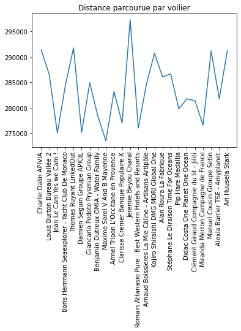

```python
plt.plot(df_latest['Crew'], df_latest['Distanceground'].values)
plt.xticks(rotation=90)
plt.title('Distance parcourue par voilier')
```

#### * Cartes avec les routes d'un ou plusieurs voiliers.

```python
latitude_num = []
for i in range(len(df['latitude'])):
    lat = re.findall(r"(\d{1,3})°(\d{1,3}).(\d{1,3})'([A-Z]{1})", df['latitude'].iloc[i])
    #print(lat)
    if (lat[0][3] == 'S'):
        latitude_num.append(-(np.round(int(lat[0][0])+int(lat[0][1])/60+int(lat[0][2])/3600, 4)))
    else:
        latitude_num.append((np.round(int(lat[0][0])+int(lat[0][1])/60+int(lat[0][2])/3600, 4)))
```

```python
longitude_num = []
for i in range(len(df['longitude'])):
    lon = re.findall(r"(\d{1,3})°(\d{1,3}).(\d{1,3})'([A-Z]{1})", df['longitude'].iloc[i])
    #print(lat)
    if (lon[0][3] == 'E'):
        longitude_num.append((np.round(int(lon[0][0])+int(lon[0][1])/60+int(lon[0][2])/3600, 4)))
    else:
        longitude_num.append(-(np.round(int(lon[0][0])+int(lon[0][1])/60+int(lon[0][2])/3600, 4)))
```

```python
df['latitude_num'] = pd.DataFrame(latitude_num)
df['longitude_num'] = pd.DataFrame(longitude_num)
df.head()
```

[output not shown]

5 rows × 39 columns

```python
df.to_csv('routes.csv')
test = pd.read_csv('routes.csv')
```

```python
skippers = test['crew'].unique()
skipper1 = skippers[0]
temp = test[test['crew']==skipper1]
nl = '\n'
vitesse_kmh = temp['speed_30'].unique()[0]
position = temp['rank'].unique()[0]
nb_skip = test['crew'].nunique()

fig = go.Figure(go.Scattermapbox(
        mode = "markers+lines",
        lon = temp['longitude_num'].values,
        lat = temp['latitude_num'].values,
        name = skipper1,
        hovertemplate = f'<b>crew</b>: {skipper1}<br>' +
                        f'<b>rank</b>: {position}<br>' +
                        f'<b>speed_30</b>: {vitesse_kmh}<br>',
        marker = {'size': 2}))

for skip in skippers[1:len(skippers)]:
    temp = test[test['crew']==skip]
    nl = '\n'
    vitesse_kmh = temp['speed_30'].unique()[0]
    position = temp['rank'].unique()[0]

    fig.add_trace(go.Scattermapbox(
        mode = "markers+lines",
        lon = temp['longitude_num'].values,
        lat = temp['latitude_num'].values,
        hovertemplate = f'<b>crew</b>: {skip}<br>' +
                        f'<b>rank</b>: {position}<br>' +
                        f'<b>speed_30</b>: {vitesse_kmh}<br>',
        name = skip,
        marker = {'size': 2}))

fig.update_layout(
    mapbox_style="white-bg",
    mapbox_layers=[
        {
            "below": 'traces',
            "sourcetype": "raster",
            "sourceattribution": "United States Geological Survey",
            "source": ["https://basemap.nationalmap.gov/arcgis/rest/services/USGSImageryOnly/MapServer/tile/{z}/{y}/{x}"]
        }
      ])
fig.update_layout(
    autosize = True,
    margin ={'l':0,'t':0,'b':0,'r':0},
    mapbox = {
        'center': {'lon': 10, 'lat': 10},
        'style': "stamen-terrain",
        'center': {'lon': -20, 'lat': -20},
        'zoom': 1})

plot(fig, validate = False, filename='plot_race.html',
   auto_open=True)
fig.show()
```

[interactive chart not shown]

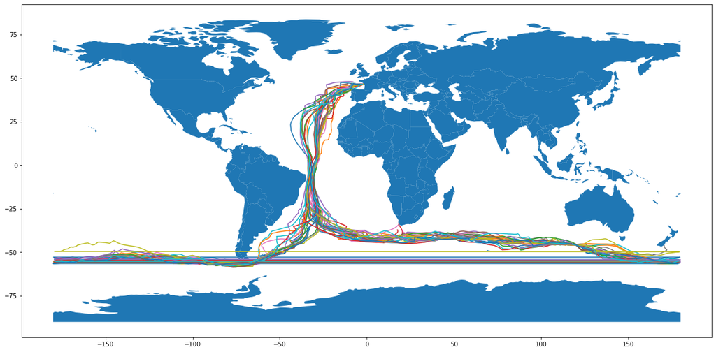

```python
fig, ax = plt.subplots(figsize=(20, 10))

world = geopandas.read_file(geopandas.datasets.get_path('naturalearth_lowres'))
world.plot(ax=ax)

# Affichage des trajectoires
for skipper in test['crew'].unique():
    tab = test.loc[(test['crew'] == skipper)]
    plt.plot(tab['longitude_num'], tab['latitude_num'])
```

#### * Analyses de séries temporelles.

```python
df['date']= pd.to_datetime(df['date'], format="%Y/%m/%d").astype(str)
df['time'] = pd.to_datetime(df['time'].astype(str), format="%H%M%S").apply(lambda x: str(x)[10:])
df['datetime'] = df['date'] + df['time']
```

[output not shown]

```python
selection = df[['date', 'numero', 'speed_30']]
```

```python
def select(numero_1, numero_2):
    return selection.loc[(selection['numero'] == numero_1) | (selection['numero'] == numero_2)]
```

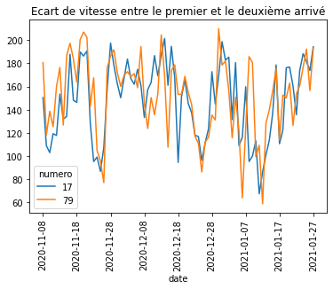

```python
# écart de vitesse entre le premier et le deuxième arrivé
selected = select(17, 79)
selected.pivot_table(index="date", columns="numero", values="speed_30", aggfunc=np.mean).plot.line()
plt.xticks(rotation=90)
plt.title('Ecart de vitesse entre le premier et le deuxième arrivé')
```

On voit que l'écart de vitesse entre le premier et le deuxième est très petit.

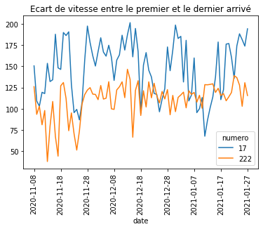

```python
# écart de vitesse entre le premier et le deuxième arrivé
selected = select(17, 222)
selected.pivot_table(index="date", columns="numero", values="speed_30", aggfunc=np.mean).plot.line()
plt.xticks(rotation=90)
plt.title("Ecart de vitesse entre le premier et le dernier arrivé")
```

L'écart de vitesse entre le premier et le dernier est grand depuis le tout début de la course.

#### * Application d'algorithmes statistiques ou de machine learning.

```python
X = pd.concat([df['speed_last'], df['foils']], axis=1).values
scaler = StandardScaler()
X = scaler.fit_transform(X)
y = df['rank'].values.reshape(-1,1)
multi_regr = linear_model.LinearRegression()
multi_regr.fit(X, y)
y_pred = multi_regr.predict(X)
r2_score(y, y_pred)
```

```
0.14315949345013868
```

La vitesse et la présence de foil fait croître r2 score, qui montre l'adéquation du modèle. Mais le résultat reste insatisfaisant.